# Analysis of uplift RCT

Tilman Bayer

2026-05-02

# Libraries and settings

```r
# whether to use the private version of the data
# or the published version (with researcher/evaluator names pseudonymized):
use_private_data <- FALSE

private_sheet_url <- "https://docs.google.com/spreadsheets/d/1bEDYkg4epbnJr5JUJ-P10KVICxhoYQhGx2CXVOOGCf8/edit"
csv_data_file <- file.path("data", "RCT_responses_cleaned.csv")
```

```r
# Seaborn "colorblind" palette, copied from SEABORN_PALETTES in:
# https://github.com/mwaskom/seaborn/blob/master/seaborn/palettes.py
# Seaborn documents "colorblind" as a named palette:
# https://seaborn.pydata.org/generated/seaborn.color_palette.html
colorblind_palette <- c(
  "#0173B2",
  "#DE8F05",
  "#029E73",
  "#D55E00",
  "#CC78BC",
  "#CA9161",
  "#FBAFE4",
  "#949494",
  "#ECE133",
  "#56B4E9"
)
```

# Ingest data

```r
# inspect data:
head(d)
```

```
##             Timestamp
##                <char>
## 1:  4/25/2026 2:45:16
## 2: 4/25/2026 17:07:00
## 3: 4/25/2026 17:40:45
## 4:  4/26/2026 0:34:40
## 5:  4/26/2026 2:38:41
## 6:  4/26/2026 3:31:49
##                                                                                           Paper Title
##                                                                                                <char>
## 1:                                   decentralization can increase cooperation among public officials
## 2:   fantastically ordered prompts and where to find them overcoming fewshot prompt order sensitivity
## 3: obfuscated gradients give a false sense of security circumventing defenses to adversarial examples
## 4:                                indecent disclosures anticorruption reforms and political selection
## 5:                                               changing tides public attitudes on climate migration
## 6:                                talking shops the effects of caucus discussion on policy coalitions
##                                                                                                                                                              Link to the paper's code (GitHub or other)
##                                                                                                                                                                                                  <char>
## 1:                                                                                                                      https://dataverse.harvard.edu/dataset.xhtml?persistentId=doi:10.7910/DVN/ZLHYSZ
## 2:                                                                                                                                                              https://github.com/yaolu/ordered-prompt
## 3:                                                                                                                                                 https://github.com/anishathalye/obfuscated-gradients
## 4:                                                                                                                      https://dataverse.harvard.edu/dataset.xhtml?persistentId=doi:10.7910/DVN/KDUMRM
## 5: https://dataverse.harvard.edu/dataset.xhtml;jsessionid=e19065118cc12d43f1b412109d41?persistentId=doi%3A10.7910%2FDVN%2FFDML2N&version=&q=&fileAccess=&fileTag=&fileSortField=name&fileSortOrder=desc
## 6:                                                                                                                      https://dataverse.harvard.edu/dataset.xhtml?persistentId=doi:10.7910/DVN/S3M5AX
##            Domain evaluator                          Agent version
##            <char>    <char>                                 <char>
## 1:            I4R         B gpt-5.4-codex with extra high thinking
## 2: AI Conferences         B
## 3: AI Conferences         B gpt-5.4-codex with extra high thinking
## 4:            I4R         C
## 5:            I4R         C gpt-5.4-codex with extra high thinking
## 6:            I4R         D
##    Execution Environment (Select “Other” only if you performed a non-standardized step.)
##                                                                                   <char>
## 1:                                          Docker instance with pre-installed libraries
## 2:                                          Docker instance with pre-installed libraries
## 3:                                          Docker instance with pre-installed libraries
## 4:                                          Docker instance with pre-installed libraries
## 5:                                          Docker instance with pre-installed libraries
## 6:                                          Docker instance with pre-installed libraries
```

[output cut: 705 more lines]

```
##                                                     <char>
## 1:
## 2:
## 3:                               N/A - no results produced
## 4:
## 5:                               N/A - no results produced
## 6:
##    Step 3.3 - Investigate discrepancies (if any) - Notes
##                                                   <char>
## 1:
## 2:
## 3:
## 4:
## 5:
## 6:
```

```r
dt <- data.table(d)
names(dt)
```

```
##   [1] "Timestamp"
##   [2] "Paper Title"
##   [3] "Link to the paper's code (GitHub or other)"
##   [4] "Domain"
##   [5] "evaluator"
##   [6] "Agent version"
##   [7] "Execution Environment (Select “Other” only if you performed a non-standardized step.)"
##   [8] "Date (PST)"
##   [9] "Start Time (PST)"
##  [10] "End Time (PST)"
##  [11] "Condition"
##  [12] "Hardware (Select “Other” only if you used an environment other than A40 on RunPod.)"
##  [13] "OS (Select “Others” only if you used an environment other than A40 on RunPod.)"
##  [14] "Phase 1 Blocker 1: What was the Blocker"
##  [15] "Phase 1 Blocker 1: Who got stuck"
```

[output cut: 96 more lines]

```r
# Retrieve column name for session duration (since it has a complicated name,
# inherited from the wording of this question in Google Forms):
duration_col <- grep("duration", names(dt), ignore.case = TRUE, value = TRUE)
if (length(duration_col) != 1) {
  stop("Expected exactly one duration column, found: ", paste(duration_col, collapse = ", "))
}

durs <- dt[[duration_col]]
```

## Histogram of session durations

```r
hist_breaks <- seq(
  floor(min(durs, na.rm = TRUE) / 15) * 15,
  ceiling(max(durs, na.rm = TRUE) / 15) * 15,
  by = 15
)
hist_xlim <- range(c(hist_breaks, 180))
hist_tick_at <- seq(
  floor(hist_xlim[1] / 30) * 30,
  ceiling(hist_xlim[2] / 30) * 30,
  by = 30
)
hist_tick_at <- hist_tick_at[hist_tick_at >= hist_xlim[1] & hist_tick_at <= hist_xlim[2]]
hist_axis_at <- sort(unique(c(hist_tick_at, hist_xlim)))
hist_axis_labels <- ifelse(hist_axis_at %in% hist_tick_at, hist_axis_at, "")
```

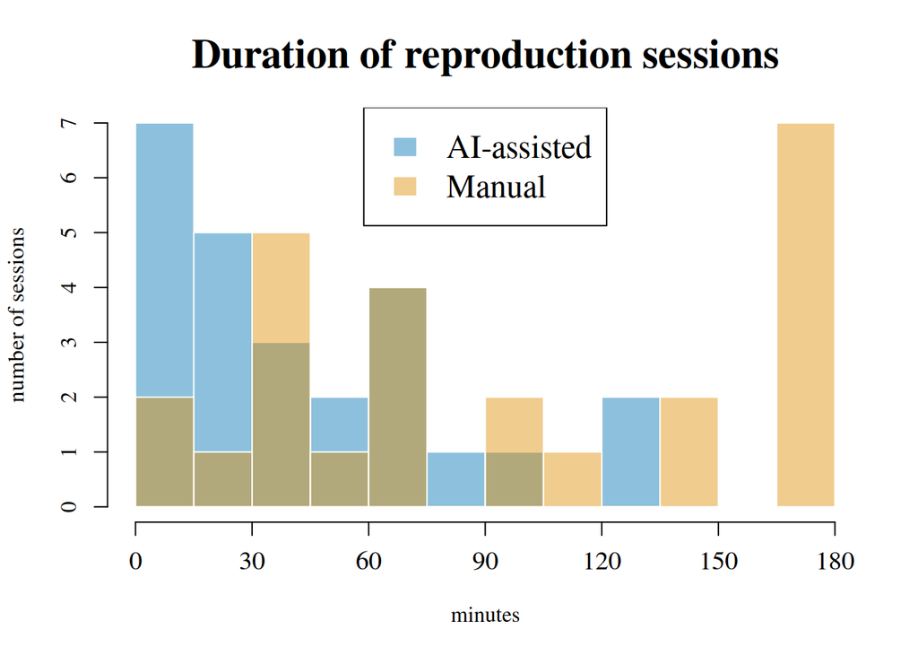

```r
condition_col <- "Condition"

duration_by_condition <- split(durs, dt[[condition_col]])
duration_by_condition <- lapply(duration_by_condition, function(x) x[!is.na(x)])
duration_by_condition <- duration_by_condition[lengths(duration_by_condition) > 0]

condition_colors <- rep(colorblind_palette, length.out = length(duration_by_condition))

hist_data <- lapply(
  duration_by_condition,
  hist,
  breaks = hist_breaks,
  plot = FALSE
)
hist_colors <- grDevices::adjustcolor(
  condition_colors,
  alpha.f = 0.45
)
hist_ylim <- c(0, max(unlist(lapply(hist_data, function(x) x[["counts"]]))))

par(family = "serif")
for (i in seq_along(hist_data)) { # loop through conditions
  plot(
    hist_data[[i]], # plot the ith histogram object
    col = hist_colors[i],
    border = "white",
    xlab = "minutes",
    ylab = "",
    main = "Duration of reproduction sessions",
    # font size magnification factors:
    cex.main = 1.875,
    cex.axis = 1.04,
    xlim = hist_xlim,
    ylim = hist_ylim,
    xaxt = "n", # suppress the default x-axis
    add = i > 1 # create plot if i=1, add plot if i>1
  )
}

# add custom x axis, and y axis label:
axis(1, at = hist_axis_at, labels = hist_axis_labels, cex.axis = 1.2)
mtext("number of sessions", side = 2, line = 3, cex = 1.04)

legend(
  "top",
  legend = names(duration_by_condition),
  fill = hist_colors,
  border = "white",
  cex = 1.5
)
```

## Uplift analysis

This regression estimates the association between condition (AI-assisted vs. Manual) and log duration. The underlying experiment was designed assuming that both researchers (evaluators) and papers (replication targets) may have unobserved characteristics that affect task duration. This motivates the use of a blocked randomization assignment (blocking on both researchers and papers), and the use of fixed effects for both in the model.

In the paper’s notation, the model is:

$$\log(\mathrm{duration}_{i}) =
\alpha
+ \beta \, \mathrm{AI}_{i}
+ \gamma_p
+ \delta_r
+ \varepsilon_i,$$

Here, $i$ indexes the individual reproduction session, $p$ denotes the paper whose result is being reproduced in $i$, and $r$ the researcher conducting the session. The terms $\gamma_p$ are paper fixed effects, $\delta_r$ are researcher fixed effects, and $\beta$ is the estimated uplift from AI assistance relative to the manual condition.

```r
condition_col <- "Condition"
reference_condition <- "AI-assisted" # estimate change relative to this condition
# Uplift is generally conceived as a speed change in this context,
# and speed is reciprocal to duration. So for simplicity we estimate
# the reciprocal factor for duration (from AI-assisted to Manual instead of vice versa).

paper_col <- "Paper Title"
researcher_col <- if (use_private_data) {
  "Human Researcher [your name]"
} else {
  "evaluator"
}

fixed_effects_regression_data <- data.frame(
  duration_minutes = durs,
  condition = relevel(factor(dt[[condition_col]]), ref = reference_condition),
  paper = factor(dt[[paper_col]]),
  researcher = factor(dt[[researcher_col]])
)
```

```r
m_fe <- lm(
  log(duration_minutes) ~ condition + paper + researcher,
  data = fixed_effects_regression_data
)

condition_effect_term <- grep(
  "^condition",
  names(coef(m_fe)),
  value = TRUE
)
if (length(condition_effect_term) != 1) {
  stop("Expected exactly one condition effect, found: ", paste(condition_effect_term, collapse = ", "))
}

condition_label <- sub("^condition", "", condition_effect_term)

# Use the actual model frame to avoid potential row-alignment problems:
mf <- model.frame(m_fe)
```

```r
V_researcher_cr2 <- vcovCR(
  m_fe,
  cluster = mf$researcher,
  type = "CR2"
)

researcher_cr2_condition_test <- coef_test(
  m_fe,
  vcov = V_researcher_cr2,
  test = "Satterthwaite",
  coefs = condition_effect_term
)
researcher_cr2_condition_log_effect <- researcher_cr2_condition_test$beta
researcher_cr2_condition_std_error <- researcher_cr2_condition_test$SE
researcher_cr2_condition_df <- researcher_cr2_condition_test$df_Satt
researcher_cr2_condition_p_value <- researcher_cr2_condition_test$p_Satt
researcher_cr2_condition_multiplier <- exp(researcher_cr2_condition_log_effect)
researcher_cr2_condition_percent_change <-
  100 * (researcher_cr2_condition_multiplier - 1)
researcher_cr2_condition_variance <- researcher_cr2_condition_std_error^2

researcher_cr2_condition_conf_int <- conf_int(
  m_fe,
  vcov = V_researcher_cr2,
  level = 0.95,
  test = "Satterthwaite",
  coefs = condition_effect_term
)
researcher_cr2_condition_log_ci <- c(
  researcher_cr2_condition_conf_int$CI_L,
  researcher_cr2_condition_conf_int$CI_U
)
researcher_cr2_condition_ratio_ci <- exp(researcher_cr2_condition_log_ci)
researcher_cr2_condition_test
```

```
## Alternative hypothesis: two-sided
##            Coef. Estimate     SE Null value t-stat d.f. (Satt) p-val (Satt)
##  conditionManual    0.748 0.0919          0   8.15        3.67      0.00176
##  Sig.
##    **
```

Using CR2 standard errors clustered by researcher, the coefficient for Manual is 0.7485, with a CR2 variance of 0.00844, a CR2 standard error of 0.0919, Satterthwaite degrees of freedom of 3.7, and p-value 0.00176. The 95% confidence interval for the effect on the log-duration scale is [0.4842, 1.0127]. The point estimate implies that Manual sessions last 2.11 times as long as AI-assisted sessions (or about 111 percent longer), with a 95% confidence interval of [1.62, 2.75] for this duration ratio.

### Additional robustness checks (not included in the paper)

```r
V_paper_cr2 <- vcovCR(
  m_fe,
  cluster = mf$paper,
  type = "CR2"
)

paper_cr2_condition_test <- coef_test(
  m_fe,
  vcov = V_paper_cr2,
  test = "Satterthwaite",
  coefs = condition_effect_term
)
paper_cr2_condition_log_effect <- paper_cr2_condition_test$beta
paper_cr2_condition_std_error <- paper_cr2_condition_test$SE
paper_cr2_condition_df <- paper_cr2_condition_test$df_Satt
paper_cr2_condition_p_value <- paper_cr2_condition_test$p_Satt
paper_cr2_condition_multiplier <- exp(paper_cr2_condition_log_effect)
paper_cr2_condition_percent_change <- 100 * (paper_cr2_condition_multiplier - 1)
paper_cr2_condition_variance <- paper_cr2_condition_std_error^2

paper_cr2_condition_test
```

```
## Alternative hypothesis: two-sided
##            Coef. Estimate    SE Null value t-stat d.f. (Satt) p-val (Satt) Sig.
##  conditionManual    0.748 0.139          0   5.38        16.4       <0.001  ***
```

Using CR2 standard errors clustered by paper, the coefficient for Manual is 0.7485, with a CR2 standard error of 0.1392, Satterthwaite degrees of freedom of 16.4, and p-value 5.65e-05. The point estimate is unchanged, but this version allows residual dependence within papers rather than within researchers.